# Sesion 02 - Aprendizaje Estadistico

Juan Carlos Martínez-Ovando

Otoño 2019

# 1 Objetivo

- En esta sesion revisaremos algunas ideas generales de los procedimientos estadisticos *inferencial* y *predictivo* basados en el **paradigma frecuentista** y el **paradigma bayesiano**.

# 2 Aprendizaje Estadístico

## 2.1 Modelos de Probabilidad

Recordemos, de la sesion anterior, que $X$ es una variable aleatoria con
$$X \sim F_X(x|\theta),$$
donde

- $F_X(\cdot)$ es una *funcion de distribuciones de probabilidad* dentro de la **clase de distribuciones**
  $$\mathcal{F}=\{F_X(x|\theta):\theta\in\Theta\}$$
- $\theta$ es un parametro (indice de modelos especificos) dentro del **espacio parametral** $\Theta$
- la variable aleatoria $X$ toma valores en el **soporte** $\mathcal{X}$.

### 2.1.1 Comentarios

- Cada modelo especifico en $\mathcal{F}$ (a.k.a. $F_X(x|\theta)$ con un valor de $\theta$ especifico) sirve para *cuantificar nuestra incertidumbre* respecto a la realizacion de la variable $X$.
- Nuestra *incertidumbre acerca de la realizacion de* $X$ se le conoce como **INCERTIDUMBRE ALEATORIA**.
- Nuestra *incertidumbre acerca del modelo especifico (valor especifico de $\theta$ en $\mathcal{F}$)* se le conoce como **INCERTIDUMBRE EPISTEMICA**.

El **aprendizaje estadistico** nos permite controlar/mitigar el efecto de la *incertiumbre epistemica* para dar una *mejor lectura* de la *incertidumbre aleatoria*.

## 2.2 Datos

> El aprendizaje estadistico toma lugar combinando el **grado de compatibilidad** entre los modelos dentro de una clase y un conjunto de informacion relevante.

La informacion relevante es de la siguiente naturaleza:

1. Informacion cuantitativa (**datos/observaciones**) del fenomeno
2. Informacion cualitativa (**suplementaria/teorica/contextual**) del fenomeno.

Los procedimientos de aprendizaje estadistico estan disenados para extrear/consolidar de la mejor manera posible ambas fuentes de informacion.

> La metrica para medir el grado de compatibilidad entre el modelo expecifico y la informacion cuantitativa disponible se obtiene a traves de la **FUNCION DE VEROSIMILITUD**.

## 2.3 Verosimilitud

Consideremos un conjunto de informacion cuantitativa/datos, dados por
$$\{x_1,x_2,\ldots,x_n\}$$
.

> Los datos no necesariamente corresponden a realizaciones de variables aleatorias, son simplemente informacion.

Vinculamos un modelo de probabilidad
$$X\sim F_X{x|\theta}$$
con esta informacion cuantitativa **suponiendo/imponiendo**
$$X_1=x_1,\ldots,X_n=x_n.$$
De esta forma, la funcion de verosimilitud de define como la probabilidad conjunta de $(x_1,\ldots,x_n)$, i.e.
$$lik(\theta;x_1,\ldots,x_n)=\Pr(X_1=x_1,\ldots,X_n=x_n|\theta)=
\begin{cases}
f_{X_1,\ldots,X_n}(x_1,\ldots,x_n|\theta), & \text{caso absolutamente continuo} \\
p_{X_1,\ldots,X_n}(x_1,\ldots,x_n|\theta), & \text{caso discreto}
\end{cases}$$
donde

- $f_{X_1,\ldots,X_n}(x_1,\ldots,x_n|\theta)$ es la funcion de densidad
- $p_{X_1,\ldots,X_n}(x_1,\ldots,x_n|\theta)$ es la funcion de masa de probabilidades,

ambas evaluadas en los datos $(x_1,\ldots,x_n)$.

> Valores grandes de $lik(\theta;x_1,\ldots,x_n)$ para un valor especifico de $\theta$ representa alta compatibilidad del modelo especifico $F_X(\cdot|\theta)$ con los datos.

El computo de $lik(\theta;x_1,\ldots,x_n)$ requiere de ciertas simplificaciones **atribuibles al modelo y no a los datos**. Tales simplificaciones hacen referencia a la forma en como **creemos** que los datos, $(x_1,\ldots,x_n)$, se relacionan entre si a traves del modelo de probabilidad $F_X(\cdot|\theta)$.

## 2.4 Dependencia estocastica

Las estructuras de dependencia estocastica alusen a la nocion de simetria en los datos a traves de $F_X(\cdot|\theta)$. En el curso trabajaremos con dos estructuras, particularmente, de cuatro que prevalecen en la modelacion actual:

1. Independencia estocastica bajo homogeneidad (caso *iid*)
2. Intercambiabilidad
3. Estacionariedad
4. Homogeneidad espacial.

De estos, solo (1) y (2) seran revisados en esta sesion.

### 2.4.1 Independencia estocastica bajo homogeneidad

En este supuesto dos condiciones prevalecen:

1. A traves del modelo $F_X(\cdot|\theta)$ las variables aleatorias $X_1,\ldots,X_n$ son mutueamente independientes, y
2. Cada variable $X_j$ es homogenea a las demas, i.e. el modelo marginal para cada variable aleatoria es el mismo, $X_j\sim F_X(\cdot|\theta)$.

Bajo estas consideraciones, es posible obtener la simplificacion

$$lik(\theta;x_1,\ldots,x_n) = \prod_{i=1}^{n} p_X(x_i;\theta),$$
para el caso discreto. La expresion es analoga para el caso absolutamente continuo.

### 2.4.2 Intercambialidad

El supuesto de intercambiabilidad es tambien de simetria, bajo el cual:

1. Cada variable aleatoria $X_j$ tiene asociado el mismo modelo marginal, i.e. $X_j\sim F_X(\cdot|\theta)$
2. El modelo de probabilidad conjunto es invariante ante permutaciones, i.e.
   $$\Pr(X_1=x_1,\ldots,X_n=x_n) =
   \Pr(X_{\sigma(1)}=x_1,\ldots,X_{\sigma(n)}=x_n),$$
   donde $\{\sigma(1),\ldots,\sigma(n)\}$ denota cualquier permutacion de los indices $\{1,\ldots,n\}$.

> Noten que en la definicion de arriba no he hecho mencion de $\theta$. Por que?

Bajo (a) y (b) arriba obtenemos que **condicional en $\theta$** las variables aleatorias $X_1,\ldots,X_n$ son independientes, por lo que la verosimilitud adopta la simplificacion

$$lik(\theta|x_1,\ldots,x_n) = \prod_{i=1}^{n} p_X(x_i|\theta),$$
para el caso discreto. La expresion es analoga al caso absolutamente continuo.

### 2.4.3 Comentarios

- Los supuestos *iid* y de *intercambialidad* hacen referencia a la nocion de simetria ante permutaciones, i.e. el modelo de probabildad no presta atencion al orden en el que los datos se manifiesten/recolecten.
- Ambos supuestos parecen ser redundantes, pero no es asi. El supuesto de intercambiabilidad implica que la correlacion entre cualquier pareja $(X_i,X_j)$, con $i\neq j$, es mayor a cero.

> El ultimo punto es de suma relevancia en el calculo del riesgo agregado.

Veamos un ejemplo con el modelo Bernoulli (el mas sencillo de este curso).

# 3 Modelo Bernoulli

Este es el modelo base para la modelacion de riesgos.

Suponemos que $X$ denota la realizacion de dos poribles resultados,
$$X =
\begin{cases}
0, & \text{ no ocurre un siniestro}\\
1, & \text{ ocurre un siniestro}.
\end{cases}$$
El soporte de esta variable aleatoria es
$$\mathcal{X}=\{0,1\}.$$

El modelo de probabilidad para esta $X$ es el Bernoulli, con
$$\begin{eqnarray}
\Pr(X=0|\theta) & = & \theta, \\
\Pr(X=1|\theta) & = & 1-\theta.
\end{eqnarray}$$

Por ser una medida de probabilidad, el espacio parametral es
$$\Theta=(0,1).$$

Este modelo lo podemos reexpresar como
$$\Pr(X=x|\theta) = \theta \delta_{\{0\}}(x) + (1-\theta)\delta_{\{1\}}(x),$$
para $x\in \mathcal{X}$.

> La funcion $\delta_{\{0\}}(x)$ se conoce como la funcion **delta de Dirac**, que es una medida de probabilidad degenerada en el atomo $\{0\}$ en este caso.

## 3.1 Datos

Consideremos el siguiente conjunto de 100 datos:

```r
shotData<- c(1, 0, 0, 0, 1, 0, 1, 0, 1, 0, 0, 0, 1, 1, 1, 0, 1, 0, 1, 1, 1, 0, 0, 1, 1, 0, 0,
             1, 1, 1, 0, 0, 1, 1, 0, 0, 0, 1, 1, 1, 0, 0, 0, 0, 1, 1, 0, 1, 1, 0, 1, 0, 0, 1,
             0, 1, 0, 1, 1, 1, 0, 1, 0, 1, 0, 0, 1, 1, 0, 1, 0, 0, 1, 1, 1, 1, 1, 1, 1, 1, 1,
             1, 1, 1, 0, 0, 1, 1, 0, 0, 1, 1, 1, 0, 1, 1, 1, 1, 1, 0)

table(shotData)
```

```
## shotData
##  0  1
## 42 58
```

La idea de la simetria estocastica hace referencia a que el modelo y el procedo de aprendizaje seran invariantes antes permutaciones del orden de los datos, i.e.

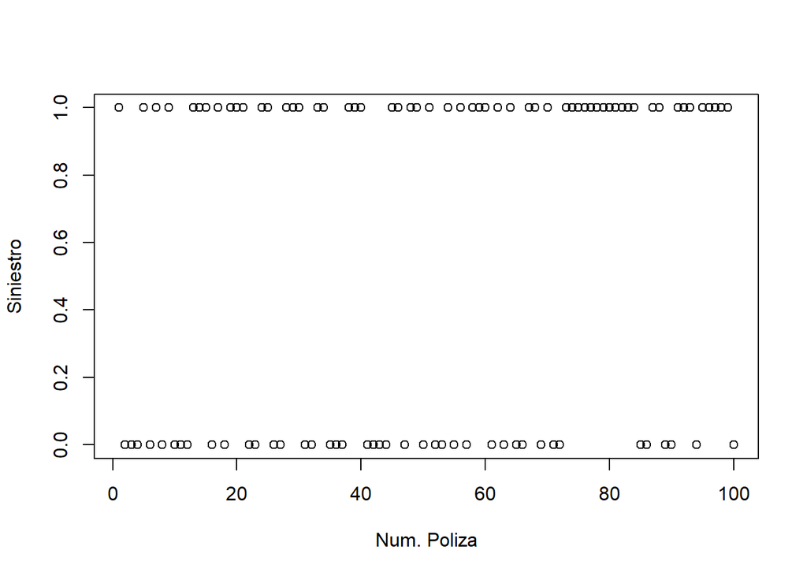

```r
plot(shotData,xlab="Num. Poliza",ylab="Siniestro")
```

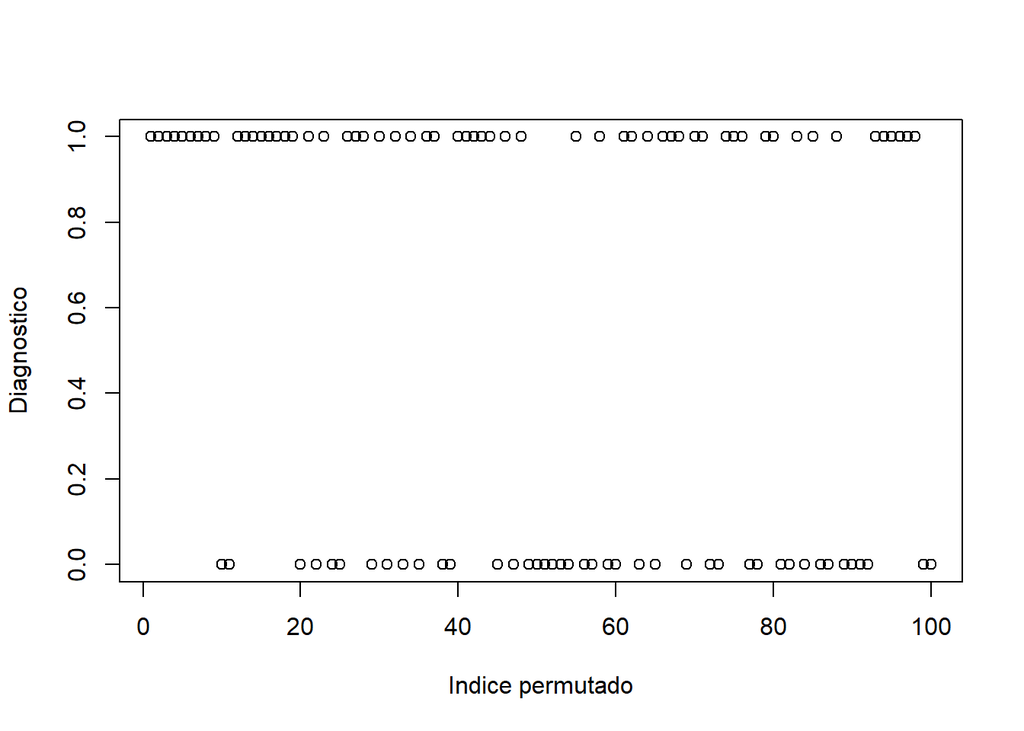

```r
plot(shotData[perm_rnd(100)[[1]]],xlab="Indice permutado",ylab="Diagnostico")
```

## 3.2 Verosimilitud

La funcion de verosimilitud, en este caso, se calcula como
$$\begin{eqnarray}
lik(\theta|\text{datos})
& = &
\prod_{i=1}^{n} \Pr(X=x_i|\theta) \\
& = &
\prod_{i=1}^{n} \left(\theta \delta_{\{0\}}(x_i) + (1-\theta)\delta_{\{1\}}(x_i)\right) \\
& = &
\prod_{\{i:x_i=0\}} \theta \delta_{\{0\}}(x_i) \prod_{\{i:x_i=1\}} (1-\theta)\delta_{\{1\}}(x_i) \\
& = &
\theta^{\#\{i:x_i=0\}} \times (1-\theta)^{\#\{i:x_i=1\}}.
\end{eqnarray}$$

> Noten que la expresion anterior es analoga tanto para el **supuesto** *iid* como el de *intercambiabilidad*.

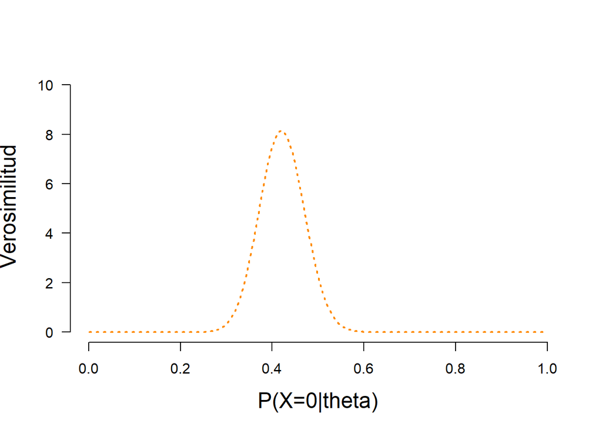

```r
x <- seq(.001, .999, .001)
y2 <- dbeta(x, 1 + 42, 1 + 58)

plot(x, y2, xlim=c(0,1), ylim=c(0, 1.25 * max(y2,1.6)), type = "l",
     ylab= "Verosimilitud", lty = 3,
     xlab= "P(X=0|theta)", las=1, lwd=2,
     cex.lab=1.5, cex.main=1.5, col = "darkorange", axes=FALSE)
axis(1, at = seq(0,1,.2))
axis(2, las=1)
```

## 3.3 Aprendizaje frecuentista

El aprendizaje estadistico frecuentista solo toma enconsideracion la *informacion cuantitativa de los datos*.

El paradigma, *grosso modo*, dicta que el mejor modelo expecifico es el que es **mas compatible con los datos**, i.e. el modelo
$$F_X(\cdot|\hat{\theta}),$$
tal que
$$\hat{\theta}=\arg\max_{\theta\in\Theta} lik(\theta|\text{datos}).$$
En este caso,
$$\hat{\theta} = 42/100.$$

Asi, el modelo especifico es:

```r
shotDatab <- table(shotData)/100
shotDatab
```

```
## shotData
##    0    1
## 0.42 0.58
```

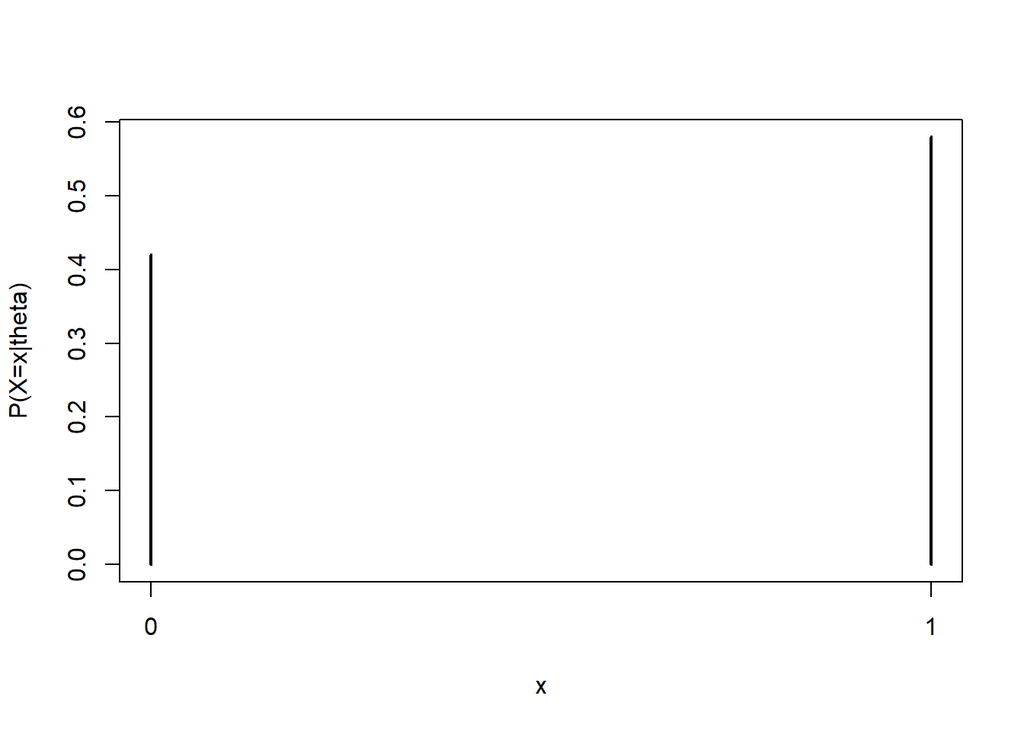

```r
plot(shotDatab, ylab='P(X=x|theta)', xlab='x')
```

> Noten que bajo la verosimilitud, *estadisticamente*, los valores de $\theta=0.45$ y $\theta=0.39$ (como otros) son extadisticamente equivalentes.

## 3.4 Aprendizaje bayesiano

El aprendizaje bayesiano consiste en combinar dos fuentes de informacion:

1. Cuantitativa
2. Cualitativa

> La informacion cualitativa se calcula con base en una **medida de probabilidad para $\theta$** con soporte en $\Theta$.

Esa medida de probabilidad se conoce como **prior** o **distribucion inicial**, y se denota por
$$\pi(\theta).$$
En este modelo particular Bernooulli, una $\pi(\theta)$ conveniente es la que sea *semejante funcionalmente a la verosimilitud*,
$$lik(\theta|\text{datos}) = \theta^{\#\{i:x_i=0\}} \times (1-\theta)^{\#\{i:x_i=1\}}.$$

En este caso, la opcion correspondientes seria la medida de probabilidad beta, con funcion de densidad
$$\begin{eqnarray}
\pi(\theta|a,b)
& = & \frac{\Gamma(a,b)}{\Gamma(a)\Gamma(b)} \theta^{a-1}(1-\theta)^{b-1}\mathbb{I}_{(0,1)}(\theta)\\
& \propto & \theta^{a-1} \times (1-\theta)^{b-1},
\end{eqnarray}$$
para $\theta \in \Theta=(0,1)$, con $a,b > 0$.

> Los valores de $a$ y $b$ se conocen como **hiperparametros** y cuantifican la **informacion cualitativa acerca del modelo especifico**.

> El procedimiento para *traducir* la **informacion cualitativa** en una **prior** se conoce como **LICITACION DE DISTRIBUCIONES** (que exploraremos a lo largo del curso).

> La informacion cualitativa es de particular importancia cuando la informacion cuantitativa es limitada. esto es relevante en varios contextos de riesgos que exploraremos en el curso.

El **aprendizaje bayesiano** toma lugar combinando la *verosimilitud* con la *prior* empleando el **Teorema de Bayes**, i.e.
$$\begin{eqnarray}
\pi(\theta|\text{datos})
& = & \frac{p(\text{datos}|\theta)\pi(\theta)}{p(\text{datos})} \\
& \propto & p(\text{datos}|\theta)\pi(\theta) \\
& \propto & lik(\theta;\text{datos})\pi(\theta) \\
& \propto & p(\text{datos}|\theta)\pi(\theta) \\
& = & \theta^{\#\{i:x_i=0\}} \times (1-\theta)^{\#\{i:x_i=1\}} \theta^{a-1} \times (1-\theta)^{b-1} \\
& = & \theta^{\#\{i:x_i=0\}+a-1} \times (1-\theta)^{\#\{i:x_i=1\}+b-1}.
\end{eqnarray}$$

Esta ultima expresion corresponde al *kernel* de la distribucion beta con parametros
$$\#\{i:x_i=0\}+a \\
\text{ y } \\
\#\{i:x_i=1\}+b.$$

> Asi como $\pi(\theta)$ se refiere a la **prior**, la nueva medida de probabilidad $\pi(\theta|\text{datos})$ se refiere a la **porterior**.

### 3.4.1 Priors

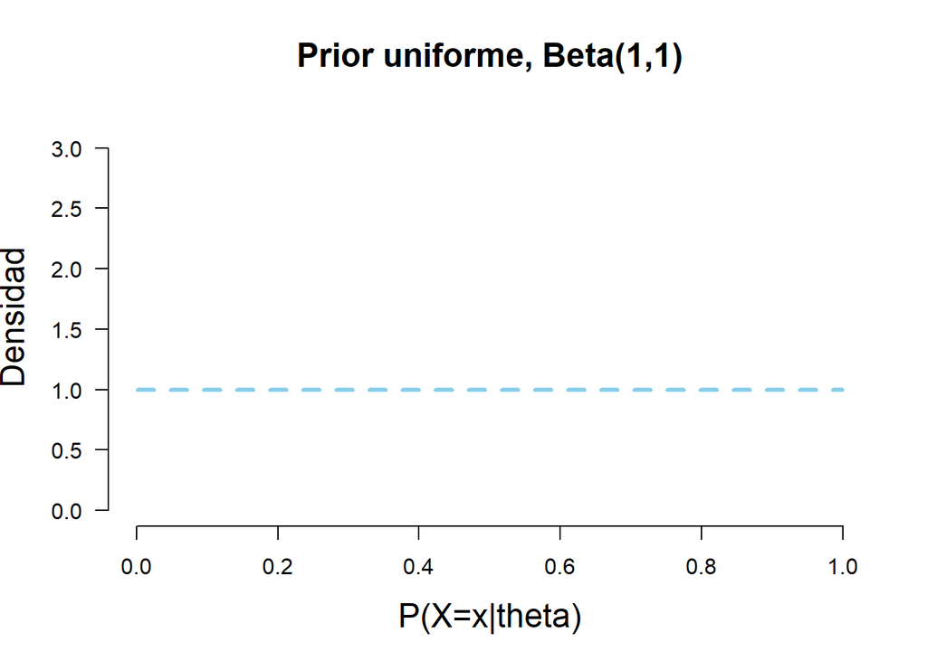

```r
plot.beta(1,1,ymax=3.2,main="Prior uniforme, Beta(1,1)")
```

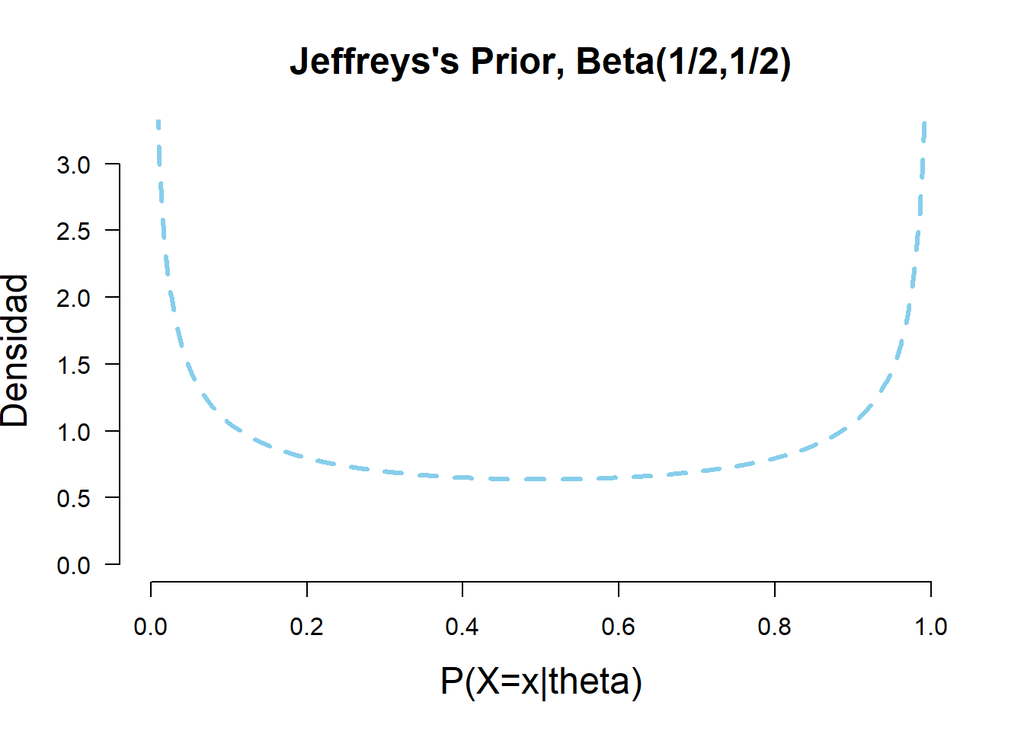

```r
plot.beta(.5,.5,ymax=3.2,main="Jeffreys's Prior, Beta(1/2,1/2)")
```

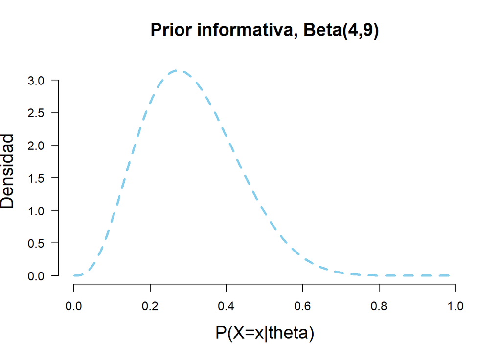

```r
plot.beta(4,9,ymax=3.2,main="Prior informativa, Beta(4,9)")
```

### 3.4.2 Posteriores

#### 3.4.2.1 Caso 1

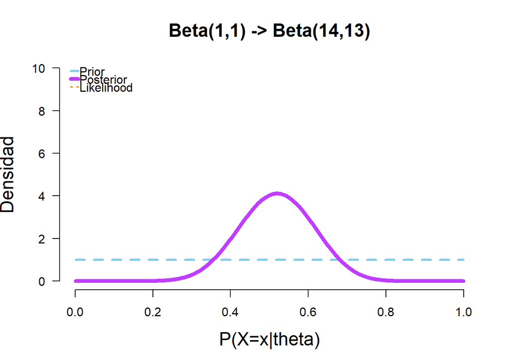

```r
plot.beta(1,1,13,25,main="Beta(1,1) -> Beta(14,13)",ymax=10)
```

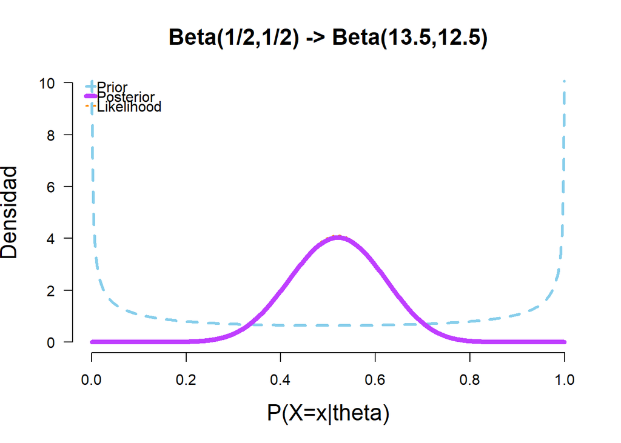

```r
plot.beta(.5,.5,13,25,main="Beta(1/2,1/2) -> Beta(13.5,12.5)",ymax=10)
```

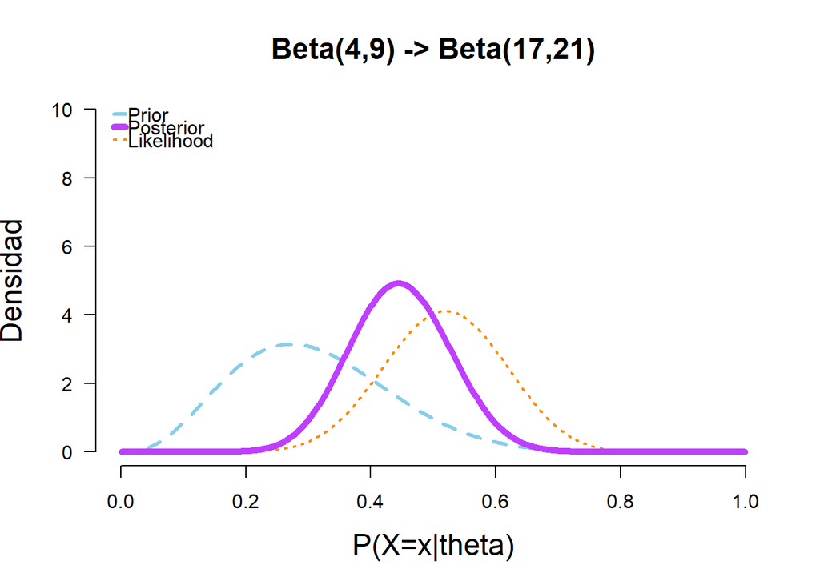

```r
plot.beta(4,9,13,25,main="Beta(4,9) -> Beta(17,21)",ymax=10)
```

#### 3.4.2.2 Caso 2

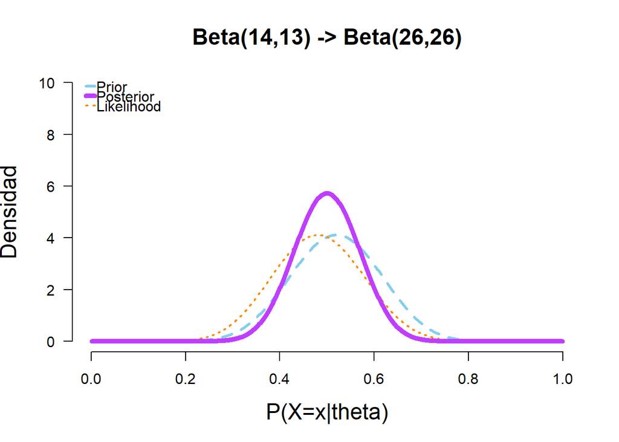

```r
plot.beta(14,13,12,25,ymax=10,main="Beta(14,13) -> Beta(26,26)")
```

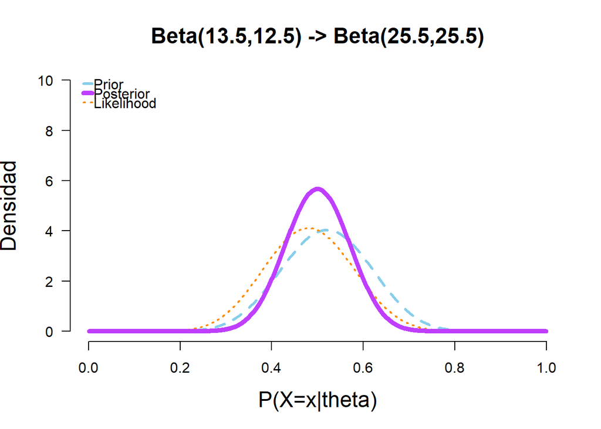

```r
plot.beta(13.5,12.5,12,25,ymax=10,main="Beta(13.5,12.5) -> Beta(25.5,25.5)")
```

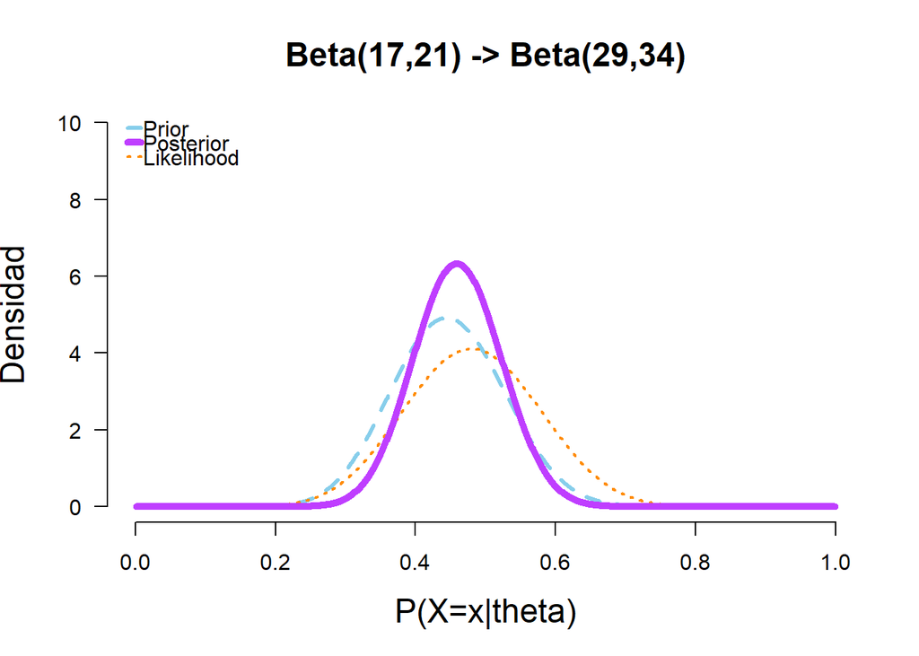

```r
plot.beta(17,21,12,25,ymax=10,main="Beta(17,21) -> Beta(29,34)")
```

#### 3.4.2.3 Caso 3

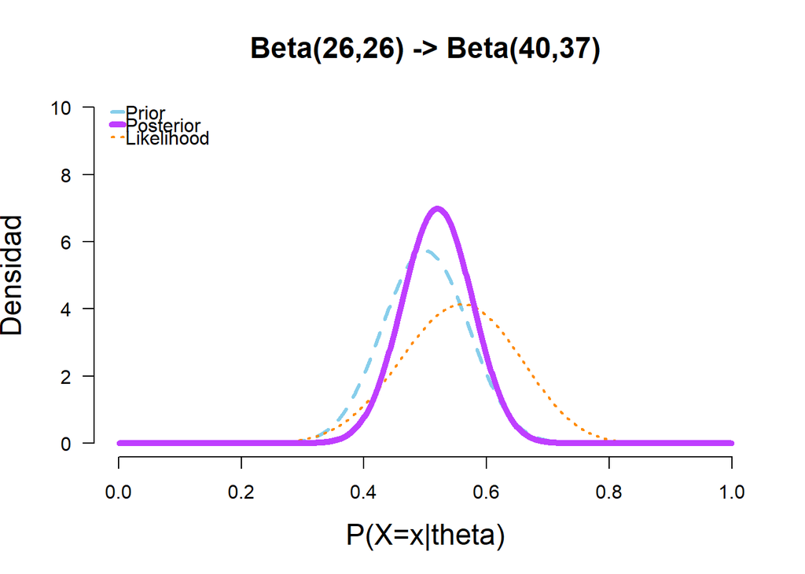

```r
plot.beta(26,26,14,25,ymax=10,main="Beta(26,26) -> Beta(40,37)")
```

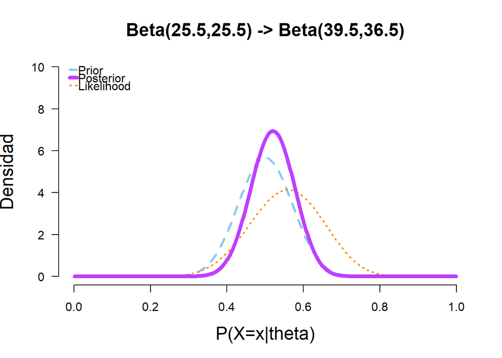

```r
plot.beta(25.5,25.5,14,25,ymax=10,main="Beta(25.5,25.5) -> Beta(39.5,36.5)")
```

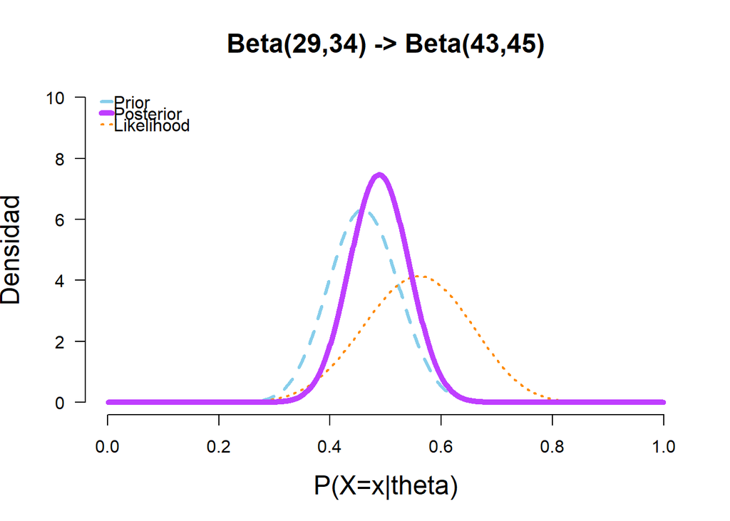

```r
plot.beta(29,34,14,25,ymax=10,main="Beta(29,34) -> Beta(43,45)")
```

#### 3.4.2.4 Caso 4

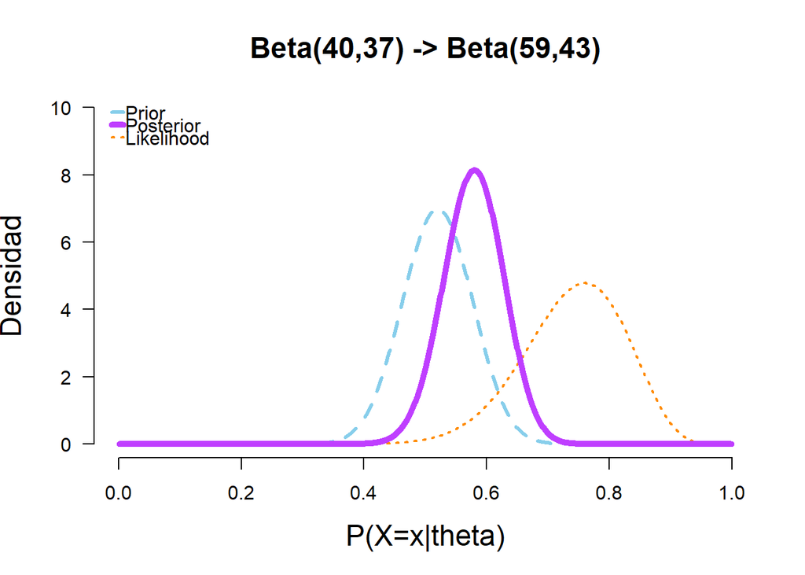

```r
plot.beta(40,37,19,25,ymax=10,main="Beta(40,37) -> Beta(59,43)")
```

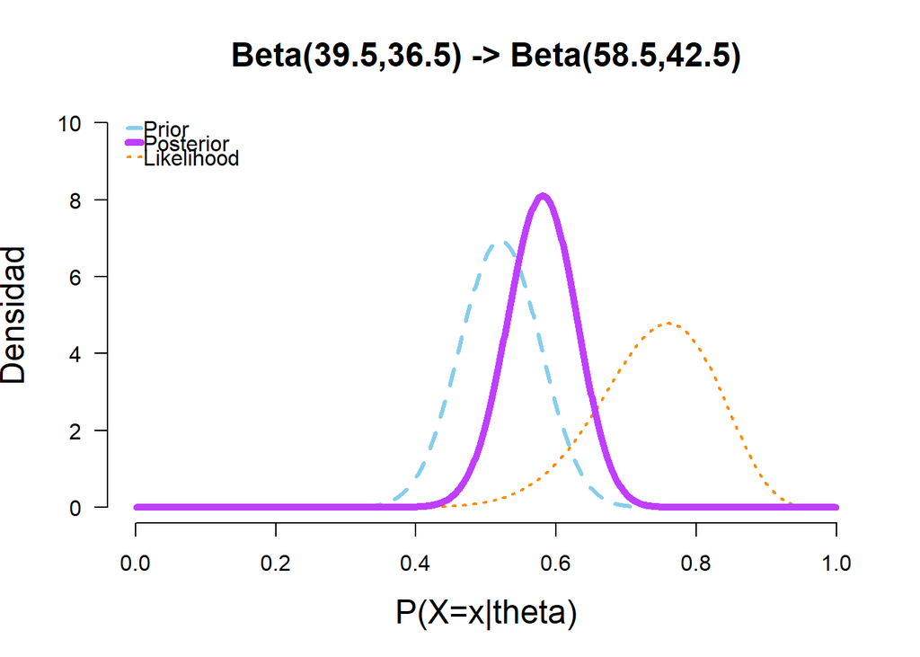

```r
plot.beta(39.5,36.5,19,25,ymax=10,main="Beta(39.5,36.5) -> Beta(58.5,42.5)")
```

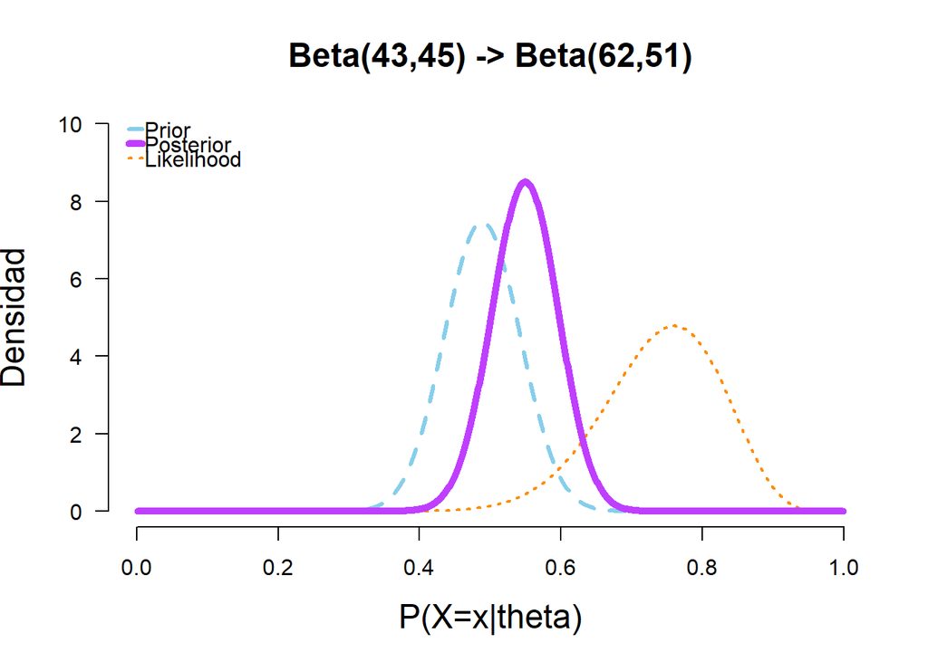

```r
plot.beta(43,45,19,25,ymax=10,main="Beta(43,45) -> Beta(62,51)")
```

#### 3.4.2.5 Caso agregado

Cuando consideramos la agregacion de todos los datos disponibles, tenemos lo siguiente:

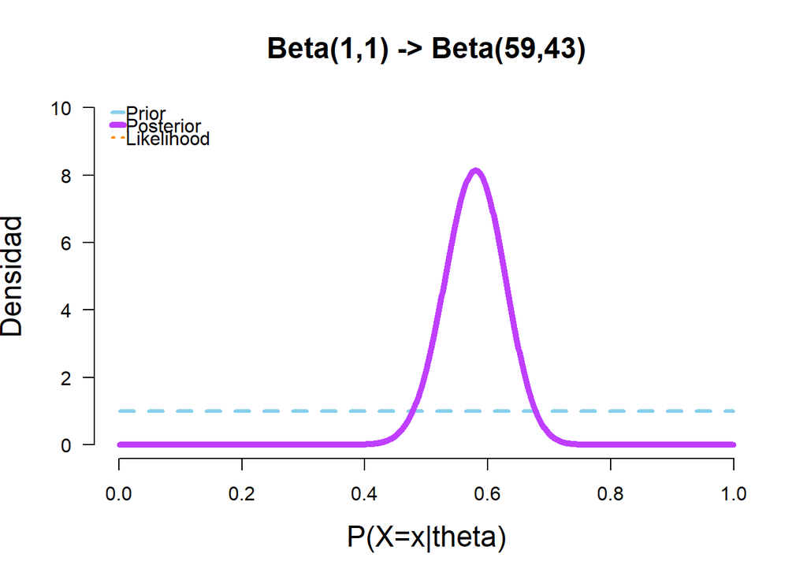

```r
plot.beta(1,1,58,100,ymax=10,main="Beta(1,1) -> Beta(59,43)")
```

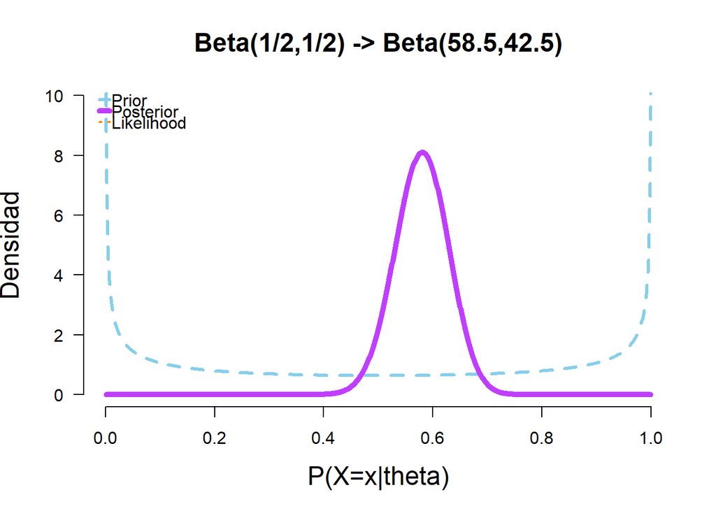

```r
plot.beta(.5,.5,58,100,ymax=10,main="Beta(1/2,1/2) -> Beta(58.5,42.5)")
```

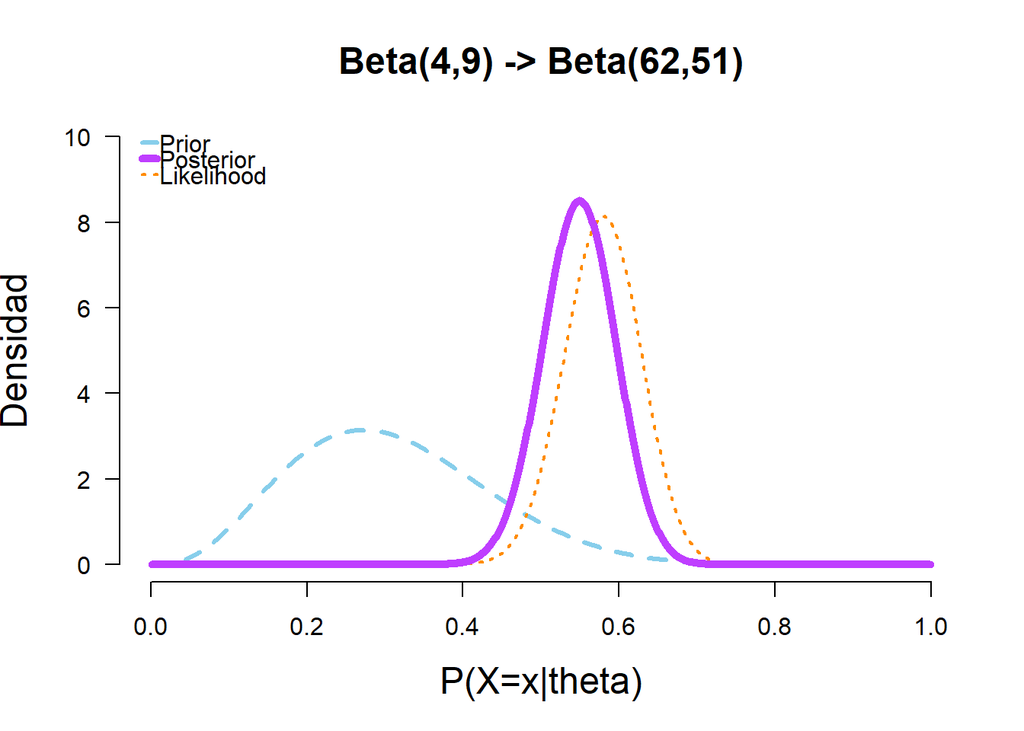

```r
plot.beta(4,9,58,100,ymax=10,main="Beta(4,9) -> Beta(62,51)")
```

# 4 Predicción

Para efectos de nuestro curso, el proposito principal de un modelo es el predictivo, es decir, anticipar lo que pasara con una y varias polizas con base en la informacion de siniestralidad (y reclamos) de polizas pasadas semejantes.

## 4.1 Enfoque frecuentista

Bajo el enfoque frecuentista, la prediccion de un valor futuro de $X$, $X^f$, se obtiene a trav'es de la imputacion del EMV de $\theta$ en el modelo, i.e.
$$\begin{equation}
X^f|x_1\ldots,x_n \sim f(x^f|\widehat{\theta}_n),
\end{equation}$$
donde $\widehat{\theta}_n=\widehat{\theta}_n(x_1\ldots,x_n)$.

> Esto porque la funcion de verosimilitud no permite incorporar el grado de diferenciacion entre diferentes modelos especificos en una escala comparable.

## 4.2 Enfoque bayesiano

Bajo el enfoque bayesiano, la predicci'on se obtiene usando argumentos probabilisticos, como
$$\begin{equation}
p(x^f|x_1\ldots,x_n) = \int_{\Theta} f(x^f|\theta) \pi(\theta|x_1\ldots,x_n)\mathrm{d}\theta,
\end{equation}$$
donde $\pi(\theta|x_1\ldots,x_n) \propto f(x_1\ldots,x_n|\theta)\pi(\theta)$ es la distribuci'on de $\theta$ actualizada con la informaci'on contenida en $x_1\ldots,x_n$.

> Esto porque la informacion cualitativa y cuantitativa consolidada en $\pi(\theta|\text{datos})$ resume toda la informacion en una medica de probabilidad comparable para todos los valores de $\theta$.

# 5 Ejercicios

Consideremos el caso sencillo donde $X$ es discreta con $\mathcal{X}=\{0,1\}$.

1. Defina el modelo de probabilidad para $X$.
2. Identifique el parametro del modelo.
3. Defina la verosimilitud para el par'ametro basado en el supuesto de $independencia$ con base en tres datos $x_1=1$, $x_2=1$ y $x_3=1$.
4. Calcule la distribuci'on predictiva para $X_4$.
5. Examine la forma gen'erica de la funci'on de verosimilitud para el par'ametro del modelo.
6. Identifique la distribucion $\pi$ conjugada (semejante).
7. Calcule la distribuci'on predictiva para $X_4$ usando los mismos datos empleados anteriormente, $x_1,x_2,x_3$.

Realicen todos los calculos en el ejercicio de manera analitica.